# Justice, Participation, and Governance

Week 5 Monday — Chapters 4 and 5

NRES 315: Human Dimensions of Fish and Wildlife Management

2026-09-16

## Why this comes after evidence and learning

Evidence, planning, and learning are essential. This week asks who is included in those processes, whose knowledge is taken seriously, and how authority is exercised.

## Today’s question

How do equity, inclusion, justice, and governance shape whether a conservation decision is legitimate and durable?

Source: Chapter 4, §4.1–4.2; Chapter 5, §5.1–5.2.

## What you should be able to do

By the end of today, you should be able to:

- identify how access, recognition, participation, and influence affect a decision;
- distinguish governance from a single agency’s day-to-day action; and
- propose one accountable process that could strengthen the durability of a conservation decision.

Source: Chapters 4–5, §§4.1–4.2 and §§5.1–5.3.

## Justice is a management condition

Access, influence, and recognition shape whether a conservation decision can be publicly legitimate.

## DEIJ is part of management practice

DEIJ shapes:

- access to land and water;
- whose knowledge is recognized;
- who bears costs and receives benefits; and
- who has influence in public processes.

Source: Chapter 4, §4.2.

## Why DEIJ matters to the profession

DEIJ has three practical implications for the profession:

- **capacity:** who enters, stays, and leads in the profession;
- **representation:** whether the profession reflects the publics it serves; and
- **relevancy:** whether conservation institutions can respond to changing communities, values, and relationships with nature.

Source: Chapter 4, §§4.3.1–4.3.3.

## Four related terms

- **Diversity:** varying attributes within a community.
- **Equity:** fair opportunity to engage and benefit, including attention to barriers.
- **Inclusion:** being accepted, supported, and able to contribute.
- **Justice:** fair practices that dismantle barriers and enable full participation.

Source: Chapter 4, Table 4.1.

## A process can include people without sharing influence

**Presence only**

People are invited, but barriers limit their participation or their knowledge has no effect on the decision.

**Meaningful inclusion**

Relevant publics can participate, their knowledge is recognized, and the process makes clear how their input can affect the decision.

Source: Chapter 4, §§4.2–4.3.

## Participation has to be designed, not announced

Meaningful participation requires more than an open meeting.

- Identify affected publics and barriers to access.
- Engage early enough for input to shape the problem and alternatives.
- Explain the scope of influence and how input was used.
- Build collaboration and accountability into the continuing relationship.

Source: Chapter 4, §4.4.2.

## Governance makes process consequential

Rules, institutions, and power determine who can decide, implement, enforce, and participate.

## Governance turns commitments into action

Governance is the interplay of rules, policies, institutions, and powers that guide decision-making, implementation, and enforcement.

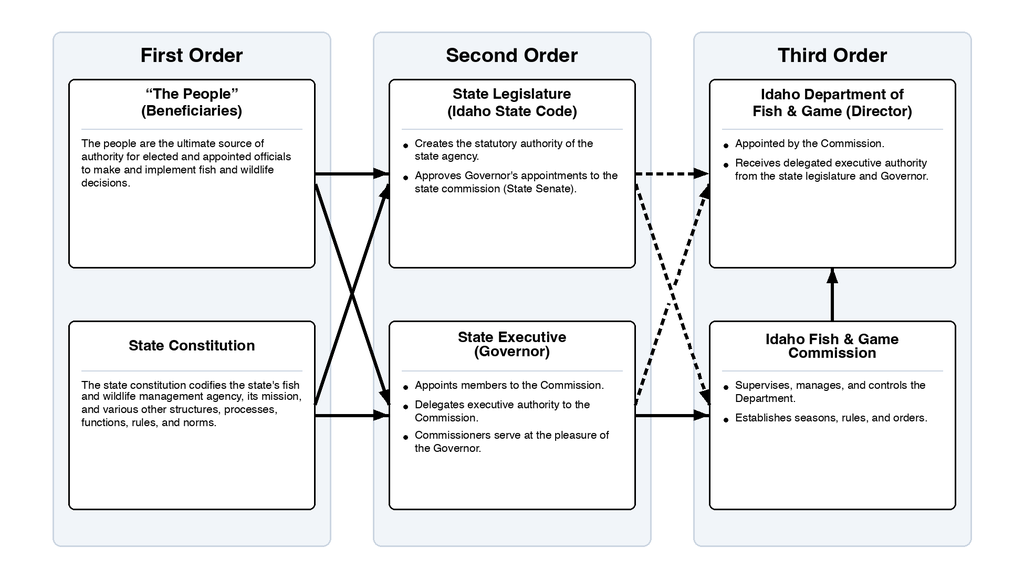

Use this governance model to identify:

- decision-making;
- implementation; and
- enforcement.

Source: Chapter 5, §5.2.

## Governance rests on competing but connected principles

Several governance foundations can pull a decision in different directions:

- deliberative democracy;
- public trust thinking;
- sustainable use; and
- the precautionary principle.

Governance is not only a chart of authority. It is also the principles used to justify how authority is exercised.

Source: Chapter 5, §§5.3.1–5.3.1.4.

## Governance asks four practical questions

1. **Authority:** Who can make or change the decision?
2. **Implementation:** Who has to carry it out?
3. **Accountability:** Who can evaluate or challenge the decision?
4. **Relationships:** Which governments, publics, and partners must be involved for the decision to work?

Source: Chapter 5, §§5.2–5.3.

## Good governance is more than biological success

Good governance is transparent, inclusive, accountable, sustainable, adaptable, and capable of coordination across boundaries.

Source: Chapter 5, §5.3.2–5.3.3.

## Funding is also a governance mechanism

Funding shapes what agencies can do, who they answer to, and which conservation work is feasible.

- Federal excise-tax programs support state fish and wildlife work.
- State, Tribal, Canadian, nongovernmental, and mitigation sources create additional pathways.
- Diverse revenue can expand capacity, while each source can also bring constraints and expectations.

Source: Chapter 5, §5.6.

## Working across knowledge traditions

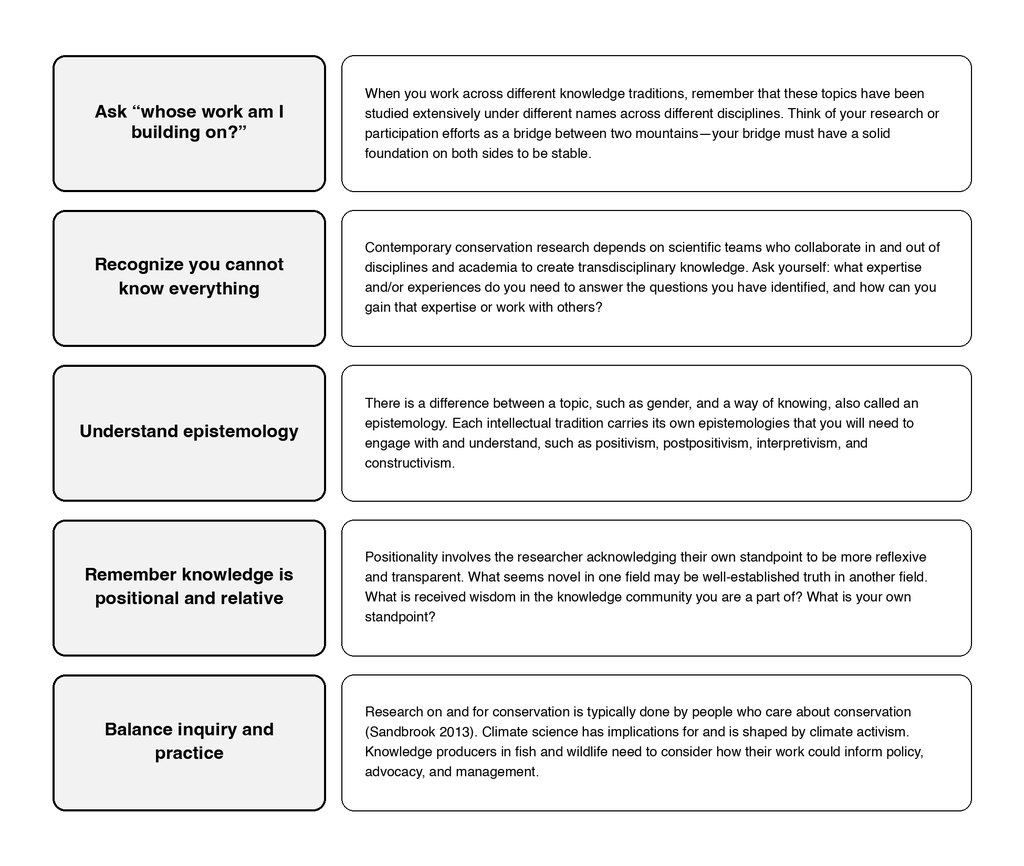

Source: Chapter 4, Figure 4.1.

## Work across knowledge traditions with humility

Work across knowledge traditions by:

- identify whose work and knowledge they are building on;
- recognize the limits of their expertise;
- understand that knowledge is positional; and
- balance inquiry with practice.

Source: Chapter 4, §4.5.2 and Figure 4.1.

## Chapter application: Grand Staircase–Escalante

Grand Staircase–Escalante became a flashpoint when many local communities and Indigenous nations felt insufficiently consulted.

Meaningful participation can shape legitimacy, trust, and durable conservation support.

Source: Chapter 4, §4.4.2.

## Diagnose the process, not only the outcome

The case asks more than whether a monument’s boundaries should be larger or smaller.

It asks whose relationships, authority, knowledge, and participation shaped the decision—and what happens when affected communities and Indigenous nations see consultation as insufficient.

Process can affect legitimacy, trust, and the durability of conservation support.

Source: Chapter 4, §4.4.2; Chapter 5, §§5.2–5.3.

## Friday preparation: four prompts

Use Chapters 4 and 5 to prepare:

1. What decision and governance context are described?
2. What DEIJ concern is visible?
3. How can consultation shape legitimacy and support?
4. What participation or collaboration practice could make a decision more durable?

## Pair rehearsal: make one accountable-process claim

With a partner, complete this claim:

> A more durable process would involve ______ early enough to ______. This matters because ______; one constraint or uncertainty is ______.

Use only a participation or collaboration practice described in Chapters 4–5.

Source: Chapters 4–5, §§4.3–4.5 and §§5.2–5.3.

## Close: a management standard

Conservation decisions are more durable when they are ecologically sound **and** publicly accountable to diverse publics, authorities, and contexts.

Source: Chapters 4–5.